# help

## Comparisons

C: control; AUD - Alcohol Use Disorder

To identify differences in AUD from a sex perspective we tested three independent comparisons. We calculate statistics to find out whether the detected change is significant, and LFC values to know the magnitude (LFC absolute value) and the direction (LFC sign) of this change. For each comparison, the meaning of the LFC is:

**AUD Impact in Females (IF comparison)**: we unveiled the differences among AUD patients and healthy individuals being female by the comparison:

*AUD females - Control females*

Direction of change can be represented qualitatively as:

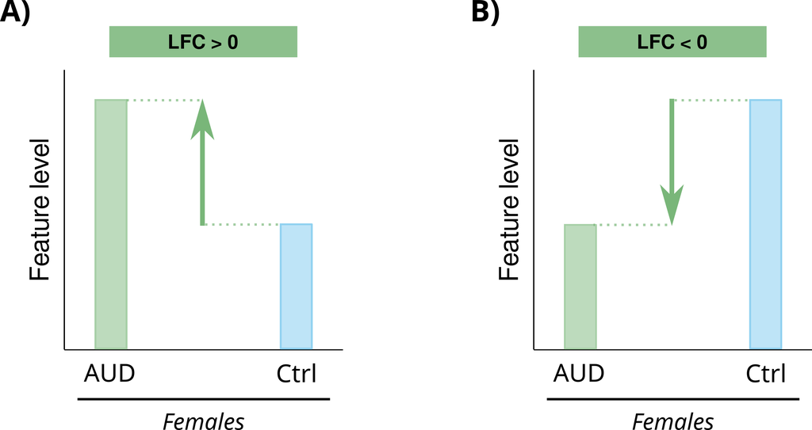

**A)** *Positive LFC (LFC > 0)* indicates that there is a higher level of the analysed characteristic in AUD females compared to control females (i.e. lower level of the analysed characteristic in control females compared to AUD females).

**B)** *Negative LFC (LFC < 0)* indicates that there is a higher level of the analysed characteristic in control females compared to AUD females (i.e. lower level of the analysed characteristic in AUD females compared to control females).

**AUD Impact in Males (IM comparison)**: we unveiled the differences among AUD patients and healthy individuals being male by the comparison:

*AUD males - Control males*

Direction of change can be represented qualitatively as:

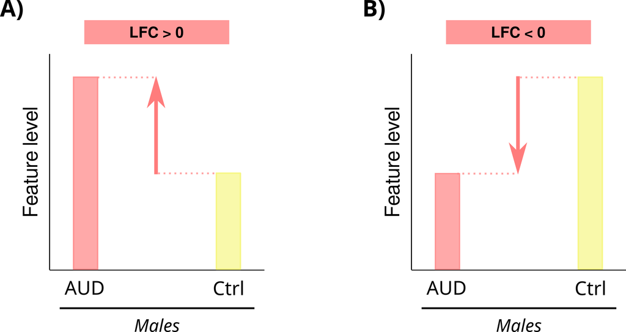

**A)** *Positive LFC (LFC > 0)* indicates that there is a higher level of the analysed characteristic in AUD males compared to control males (i.e. lower level of the analysed characteristic in control males compared to AUD males).

**B)** *Negative LFC (LFC < 0)* indicates that there is a higher level of the analysed characteristic in control males compared to AUD males (i.e. lower level of the analysed characteristic in AUD males compared to control males).

**Impact of Sex in AUD (IS comparison)**: we unveiled sex differences among AUD patients without considering the inherent sex variability in healthy individuals, that is, finding differences between IF and IM by the comparison:

*(AUD females - Control females) - (AUD males - Control males)*

Direction of change can be represented qualitatively as:

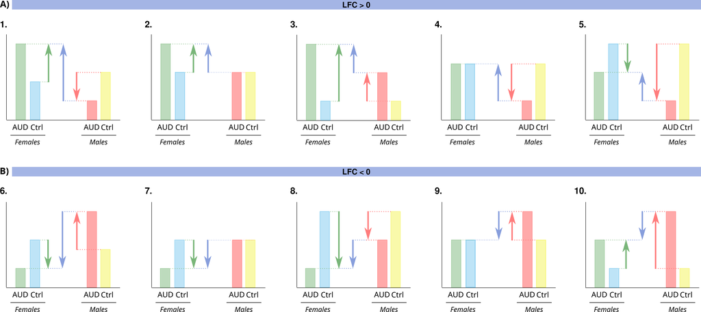

**A)** *Positive LFC (LFC > 0)* indicates a sex-differential increase of the feature in females compared to males (i.e. a sex-differential decrease of the feature in males compared to females). Patterns that could lead to this result are:

1. positive LFCs in IF and negative LFCs in IM
2. positive LFCs in IF without significant changes in IM
3. positive LFCs in both IF and IM but larger in IF
4. negative LFCs in IM without significant changes in IF
5. negative LFCs in both IF and IM but larger in IM

**B)** *Negative LFC (LFC < 0)* indicates a sex-differential increase of the feature in males compared to females (i.e. a sex-differential decrease of the feature in females compared to males). Patterns that could lead to this result are:

6. negative LFCs in IF and positive LFCs in IM
7. negative LFCs in IF without significant changes in IM
8. negative LFCs in both IF and IM but larger in IF
9. positive LFCs in IM without significant changes in IF
10. positive LFCs in both IF and IM but larger in IM

## Differential expression analysis (DEA) of miRNAs

## Functional profiling section

## Study overview

This section includes the outline of dataset selection, the summary of selected datasets and the detailed technical description of the bioinformatic analysis.